# Time & Space Prediction: The case of Philly Bike Share

### 5.2 Generalizability

In this section, we selected the Time_Space_FE_timeLags_holidayLags_5 model (reg5), which has the best predictive ability,for further examination of generalizability.

If we plot observed vs. predicted of our model for different times of day during the week and weekend, some patterns begin to emerge. We are certainly underpredicting in general, but what do we begin to see about some of the outcomes that our model cannot explain? In order to answer the above question, we decide to examine the generalizability of the model from several perspectives: space, time and demographic dimensions.

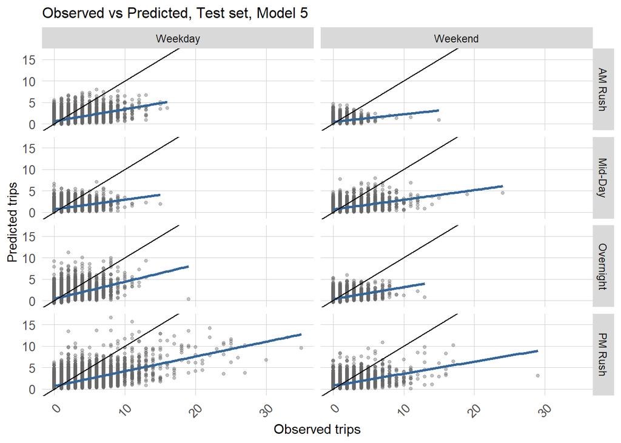

```r
week_predictions %>%
  mutate(interval60 = map(data, pull, interval60),
         from_station_id = map(data, pull, start_station),
         from_latitude = map(data, pull, start_lat),
         from_longitude = map(data, pull, start_lon),
         dotw = map(data, pull, dotw)) %>%
  select(interval60, from_station_id, from_longitude,
         from_latitude, Observed, Prediction, Regression,
         dotw) %>%
  unnest() %>%
  filter(Regression == "Time_Space_FE_timeLags_holidayLags_5")%>%
  mutate(weekend = ifelse(dotw %in% c("Sun", "Sat"), "Weekend", "Weekday"),
         time_of_day = case_when(hour(interval60) < 7 | hour(interval60) > 18 ~ "Overnight",
                                 hour(interval60) >= 7 & hour(interval60) < 10 ~ "AM Rush",
                                 hour(interval60) >= 10 & hour(interval60) < 15 ~ "Mid-Day",
                                 hour(interval60) >= 15 & hour(interval60) <= 18 ~ "PM Rush"))%>%
  ggplot()+
  geom_point(aes(x= Observed, y = Prediction),size=1,alpha = 0.4,color="#666666")+
  geom_smooth(aes(x= Observed, y= Prediction), method = "lm", se = FALSE, color = "#336699")+
  geom_abline(slope = 1, intercept = 0,color="black")+
  facet_grid(time_of_day~weekend)+
  labs(title="Observed vs Predicted, Test set, Model 5",
       x="Observed trips",
       y="Predicted trips")+
  plotTheme()
```

### 5.2.1 validate test set by space

At the very first beginning, we looked at the errors of the model on a map by neighborhood. The highest trip count MAE occurs in the central city area, where more trips obviously occur. Besides, it seem that the model is better at predicting in time than in space.

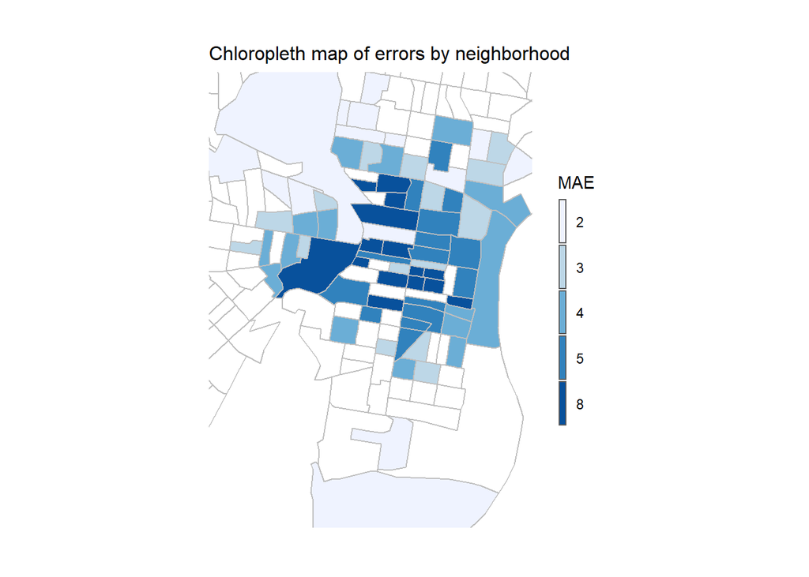

```r
# chloropleth map of errors by neighborhood, Model 5
filter(week_predictions, Regression == "Time_Space_FE_timeLags_holidayLags_5") %>%
  unnest() %>%
  left_join(., tracts, by = c("Origin.Tract" = "GEOID")) %>%
  st_sf() %>%
  dplyr::select(Origin.Tract, Absolute_Error, geometry) %>%
  gather(Variable, Value, -Origin.Tract, -geometry) %>%
  group_by(Variable, Origin.Tract) %>%
  na.omit() %>%
  summarize(MAE = mean(Value)) %>%
  ggplot() +
  geom_sf(aes(fill = q5(MAE))) +
  scale_fill_manual(values = palette5,
                    labels = c("2", "3", "4", "5", "8"),
                    name = "MAE") +
  labs(title="Chloropleth map of errors by neighborhood") +
  mapTheme()+
  ylim(min(dat_tracts$start_lat), max(dat_tracts$start_lat))+
  xlim(min(dat_tracts$start_lon), max(dat_tracts$start_lon))+
  geom_sf(data=tracts,color = "grey", fill = "transparent")
```

### 5.2.2 validate test set by time

To further investigate the temporal pattern to these big errors, we map the MAE of our model by time-space.Seems like these central city errors increase during the AM Rush and PM Rush on weekday, as well as the Mid-day and PM Rush on weekend, which means the predictive ability of our model decrease during these periods.

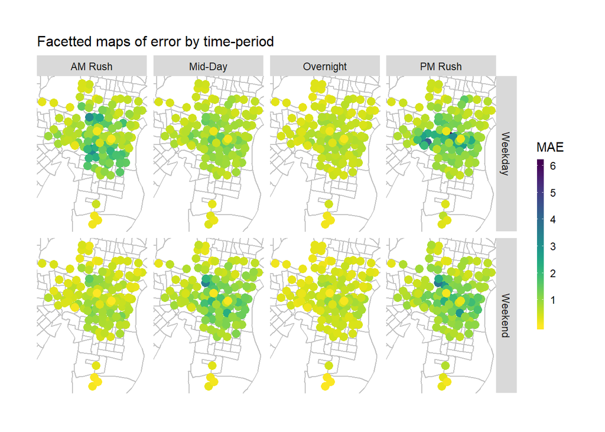

```r
# facetted maps  of error by time-period, Model 5
week_predictions %>%
  mutate(interval60 = map(data, pull, interval60),
         start_station = map(data, pull,start_station),
         start_lat = map(data, pull, start_lat),
         start_lon = map(data, pull, start_lon),
         dotw = map(data, pull, dotw) ) %>%
  select(interval60, start_station,start_lon,
         start_lat, Observed, Prediction, Regression,
         dotw) %>%
  unnest() %>%
  filter(Regression == "Time_Space_FE_timeLags_holidayLags_5")%>%
  mutate(weekend = ifelse(dotw %in% c("Sun", "Sat"), "Weekend", "Weekday"),
         time_of_day = case_when(hour(interval60) < 7 | hour(interval60) > 18 ~ "Overnight",
                                 hour(interval60) >= 7 & hour(interval60) < 10 ~ "AM Rush",
                                 hour(interval60) >= 10 & hour(interval60) < 15 ~ "Mid-Day",
                                 hour(interval60) >= 15 & hour(interval60) <= 18 ~ "PM Rush")) %>%
  group_by(start_station, weekend, time_of_day, start_lon, start_lat) %>%
  summarize(MAE = mean(abs(Observed-Prediction), na.rm = TRUE))%>%
  ggplot(.)+
  geom_sf(data = tracts, color = "grey", fill = "transparent")+
  geom_point(aes(x = start_lon, y = start_lat, color = MAE),
             fill = "transparent", size =3)+
  scale_colour_viridis(direction = -1,
                       discrete = FALSE, option = "D")+
  ylim(min(dat_tracts$start_lat), max(dat_tracts$start_lat))+
  xlim(min(dat_tracts$start_lon), max(dat_tracts$start_lon))+
  facet_grid(weekend~time_of_day)+
  labs(title="Facetted maps of error by time-period")+
  mapTheme()
```

### 5.2.3 validate test set by demographic dimensions

In addition, we also explored the relationship between the rideshare trips and the demographic variables. As can be seen from the following figures, the percent_Taking_Public_Trans and Percent_White demographic variable are strongly associated with the MAE.To be more specific,our model performs better in the area which has a high percent of people who take public transport to travel, or the area which has a low percent of the white.

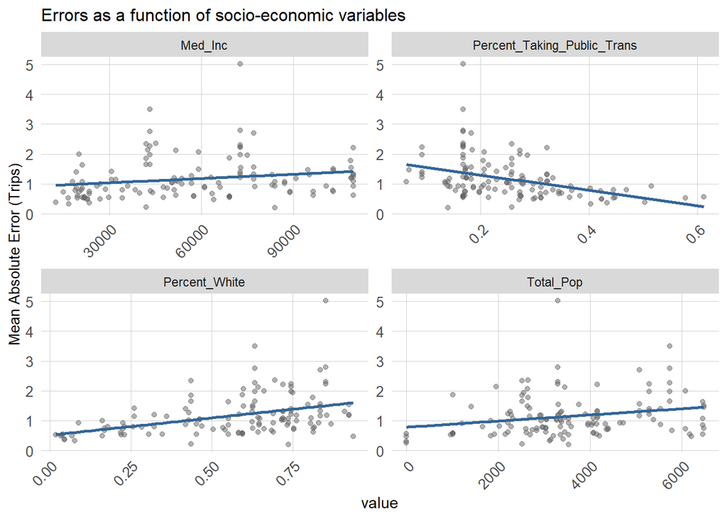

```r
week_predictions %>%
  mutate(interval60 = map(data, pull, interval60),
         start_station = map(data, pull, start_station),
         start_lat = map(data, pull, start_lat),
         start_lon = map(data, pull,start_lon),
         dotw = map(data, pull, dotw),
         Med_Inc = map(data, pull, Med_Inc),
         Total_Pop = map(data, pull,Total_Pop),
         Percent_White = map(data, pull,Percent_White),
         Percent_Taking_Public_Trans = map(data, pull,Percent_Taking_Public_Trans))%>%
  select(interval60, start_station, start_lon,
         start_lat, Observed, Prediction, Regression,
         dotw, Med_Inc,Total_Pop,Percent_White,Percent_Taking_Public_Trans) %>%
  unnest() %>%
  filter(Regression == "Time_Space_FE_timeLags_holidayLags_5")%>%
  mutate(weekend = ifelse(dotw %in% c("Sun", "Sat"), "Weekend", "Weekday"),
         time_of_day = case_when(hour(interval60) < 7 | hour(interval60) > 18 ~ "Overnight",
                                 hour(interval60) >= 7 & hour(interval60) < 10 ~ "AM Rush",
                                 hour(interval60) >= 10 & hour(interval60) < 15 ~ "Mid-Day",
                                 hour(interval60) >= 15 & hour(interval60) <= 18 ~ "PM Rush")) %>%
  filter(time_of_day == "PM Rush") %>%
  group_by(start_station, Med_Inc,Total_Pop,Percent_White,Percent_Taking_Public_Trans) %>%
  summarize(MAE = mean(abs(Observed-Prediction), na.rm = TRUE))%>%
  gather(-start_station, -MAE, key = "variable", value = "value")%>%
  ggplot(.)+
  geom_point(aes(x = value, y = MAE), alpha = 0.5,color="#666666")+
  geom_smooth(aes(x = value, y = MAE), method = "lm", se= FALSE,color="#336699")+
  facet_wrap(~variable, scales = "free")+
  labs(title="Errors as a function of socio-economic variables",
       y="Mean Absolute Error (Trips)")+
  plotTheme()
```

## 6. Discussion

In general, the model we built does exist some flaws: it miss the peaks, and underpredict for periods of high demand. However,we still believe that our model is an effective model, since it is accurate to less than an average of one ride per hour, which pretty alright for overall accuracy.Also, our model is able to track the time components of demand,that is, though this model does not capture the magnitude of the highest demand, it does capture the timing of the highest demand,which is useful insight for bike allocation. Besides,we stand that our model worth to be recommanded to be put into production in some specific area: for those tracts that have a high percent of people who take public transport to travel, or have a low percent of the white, our model still has good predictive power. In order to improve our algorithm in the future, we could add more effective features into our model, such as traffic conditions and socioeconomic disparities, etc.